[O’Hara on GitHub](https://github.com/oharac)

# Upstream/downstream cross validation

Compiled on Thu Aug 12 12:18:42 2021 by ohara

```r
knitr::opts_chunk$set(fig.width = 6, fig.height = 4, fig.path = 'figs/',
                      echo = TRUE, message = FALSE, warning = FALSE)

library(oharac) ### remotes::install_github('oharac/oharac')
oharac::setup()
source(here('common_fxns.R'))
options(dplyr.summarise.inform = FALSE)
```

# 1 Summary

Use a cross-validation technique to estimate the error/uncertainty in the upstream-downstream gapfilling process. Starting with the body of species groups provided by experts, use the downfill process to estimate vulnerability for as many “given” species as possible. Next, identify given species whose vulnerability could be gapfilled using an upstream/downstream gapfill process.

- Identify all species whose vulnerability is calculated from traits at species level.
- Looping over these species, attempt to gapfill at genus level, using other species given at the species level to calculate a weighted average.
- Repeat at family level, then order level.

# 2 Data

Data is calculated from pre-gapfilled vulnerability score files created in script 5:

- `~/git-annex/spp_vuln/pre_gapfill/vuln_gapfill_values.csv`
- `~/git-annex/spp_vuln/pre_gapfill/vuln_gapfill_taxa.csv`

# 3 Methods

## 3.1 Read in vulnerability scores and identify candidates for cross validation

To be eligible for cross-validation, a species must be a member of a genus with two or more species represented (otherwise, nothing to cross-validate from).

```r
vuln_vals <- read_csv('~/git-annex/spp_vuln/pre_gapfill/vuln_gapfill_values.csv')
vuln_tx <- read_csv('~/git-annex/spp_vuln/pre_gapfill/vuln_gapfill_taxa.csv')

vuln_df <- vuln_vals %>%
  full_join(vuln_tx, by = 'tx_id')

spp_df <- vuln_df %>%
  filter(match_rank == 'species') %>%
  # group_by(class, order, family, genus) %>%
  # filter(n_distinct(species) > 1) %>%
  ungroup()
```

## 3.2 Cross-validate at species level

Leave-one-out cross validation will drop one species at a time, recalculate vulnerability across all stressors based on other species within the same taxonomic group (genus, family, etc).

The results will be compared to the directly-calculated vulnerability scores. For each taxonomic group and stressor, an RMS difference will be calculated to estimate the uncertainty in upstream/downstream gapfilling.

```r
calc_xval <- function(name, df, r_at, r_up) {
  ### r_up <- 'genus'; r_at <- 'species'
  ### name <- spp_vec[1]
  ### df <- spp_df
  tmp_df <- df %>%
    rename(tmp_up := !!r_up,
           tmp_at := !!r_at)

  loocv_df <- tmp_df %>%
    group_by(tmp_up) %>%
    filter(n_distinct(tmp_at) > 1) %>%
    filter(name %in% tmp_at) %>%
    filter(tmp_at != name) %>%
    group_by(stressor) %>%
    summarize(vuln_xv = mean(vuln),
              sd_vuln_xv = sqrt(sum(sd_vuln^2, na.rm = TRUE)))

  left_out_df <- tmp_df %>%
    filter(tmp_at == name) %>%
    select(taxon, stressor, !!r_up := tmp_up, !!r_at := tmp_at, vuln, sd_vuln) %>%
    distinct()

  loocv_result <- left_out_df %>%
    left_join(loocv_df, by = 'stressor') %>%
    filter(!is.na(vuln_xv))

  return(loocv_result)
}
```

```r
spp_vec <- unique(spp_df$species)

xval_s_g_df <- parallel::mclapply(spp_vec, mc.cores = 20,
                                  FUN = calc_xval,
                                  df = spp_df, r_at = 'species', r_up = 'genus') %>%
  bind_rows()

xval_s_f_df <- parallel::mclapply(spp_vec, mc.cores = 20,
                                  FUN = calc_xval,
                                  df = spp_df, r_at = 'species', r_up = 'family') %>%
  bind_rows()

xval_s_o_df <- parallel::mclapply(spp_vec, mc.cores = 20,
                                  FUN = calc_xval,
                                  df = spp_df, r_at = 'species', r_up = 'order') %>%
  bind_rows()

xval_s_c_df <- parallel::mclapply(spp_vec, mc.cores = 20,
                                  FUN = calc_xval,
                                  df = spp_df, r_at = 'species', r_up = 'class') %>%
  bind_rows()
```

```r
summarize_xval <- function(xval_df, vars) {
  xval_summary <- xval_df %>%
    group_by(across(all_of(vars))) %>%
    mutate(vuln_diff = vuln - vuln_xv,
           sd_vuln_diff = sd_vuln - sd_vuln_xv) %>%
    summarize(rmse_vuln = sqrt(mean(vuln_diff^2)),
              rmse_sd_vuln = sqrt(sum(sd_vuln_diff^2, na.rm = TRUE) / n()),
              v_mean = mean(vuln),
              sd_v_mean = 1/n() * sqrt(sum(sd_vuln^2, na.rm = TRUE)),
              n_in_group = n(),
              .groups = 'drop')
}

xval_s_g_sum <- summarize_xval(xval_s_g_df, c('taxon', 'stressor')) %>%
  mutate(rmse_over_mean = rmse_vuln / v_mean)
xval_s_f_sum <- summarize_xval(xval_s_f_df, c('taxon', 'stressor')) %>%
  mutate(rmse_over_mean = rmse_vuln / v_mean)
xval_s_o_sum <- summarize_xval(xval_s_o_df, c('taxon', 'stressor')) %>%
  mutate(rmse_over_mean = rmse_vuln / v_mean)
xval_s_c_sum <- summarize_xval(xval_s_c_df, c('taxon', 'stressor')) %>%
  mutate(rmse_over_mean = rmse_vuln / v_mean)
```

```r
compare_rmse_df <- xval_s_g_sum %>%
  select(taxon, stressor, genus = rmse_vuln, n_g = n_in_group) %>%
  full_join(xval_s_f_sum %>% select(taxon, stressor, family = rmse_vuln, n_f = n_in_group),
            by = c('taxon', 'stressor')) %>%
  full_join(xval_s_o_sum %>% select(taxon, stressor, order = rmse_vuln, n_o = n_in_group),
            by = c('taxon', 'stressor')) %>%
  full_join(xval_s_c_sum %>% select(taxon, stressor, class = rmse_vuln, n_c = n_in_group),
            by = c('taxon', 'stressor')) %>%
  mutate(across(where(is.numeric), ~round(.x, 4)))

DT::datatable(compare_rmse_df)
```

|  | taxon | stressor | genus | n_g | family | n_f | order | n_o | class | n_c |
| --- | --- | --- | --- | --- | --- | --- | --- | --- | --- | --- |
| 1 | cephalopods | air_temp | 0 | 161 | 0 | 204 | 0 | 218 | 0 | 220 |
| 2 | cephalopods | biomass_removal | 0.0055 | 161 | 0.0083 | 204 | 0.0182 | 218 | 0.0266 | 220 |
| 3 | cephalopods | bycatch | 0.0306 | 161 | 0.0478 | 204 | 0.0688 | 218 | 0.0732 | 220 |
| 4 | cephalopods | entanglement_macroplastic | 0.017 | 161 | 0.04 | 204 | 0.0629 | 218 | 0.0694 | 220 |
| 5 | cephalopods | eutrophication_nutrient_pollution | 0.0053 | 161 | 0.0062 | 204 | 0.0123 | 218 | 0.0354 | 220 |
| 6 | cephalopods | habitat_loss_degradation | 0.0022 | 161 | 0.0038 | 204 | 0.0128 | 218 | 0.0173 | 220 |
| 7 | cephalopods | inorganic_pollution | 0.0207 | 161 | 0.0232 | 204 | 0.0281 | 218 | 0.0335 | 220 |
| 8 | cephalopods | invasive_species | 0 | 161 | 0 | 204 | 0 | 218 | 0 | 220 |
| 9 | cephalopods | light_pollution | 0.0391 | 161 | 0.0438 | 204 | 0.0675 | 218 | 0.0904 | 220 |
| 10 | cephalopods | noise_pollution | 0.0015 | 161 | 0.0026 | 204 | 0.0056 | 218 | 0.0092 | 220 |

[output cut: 166 more lines]

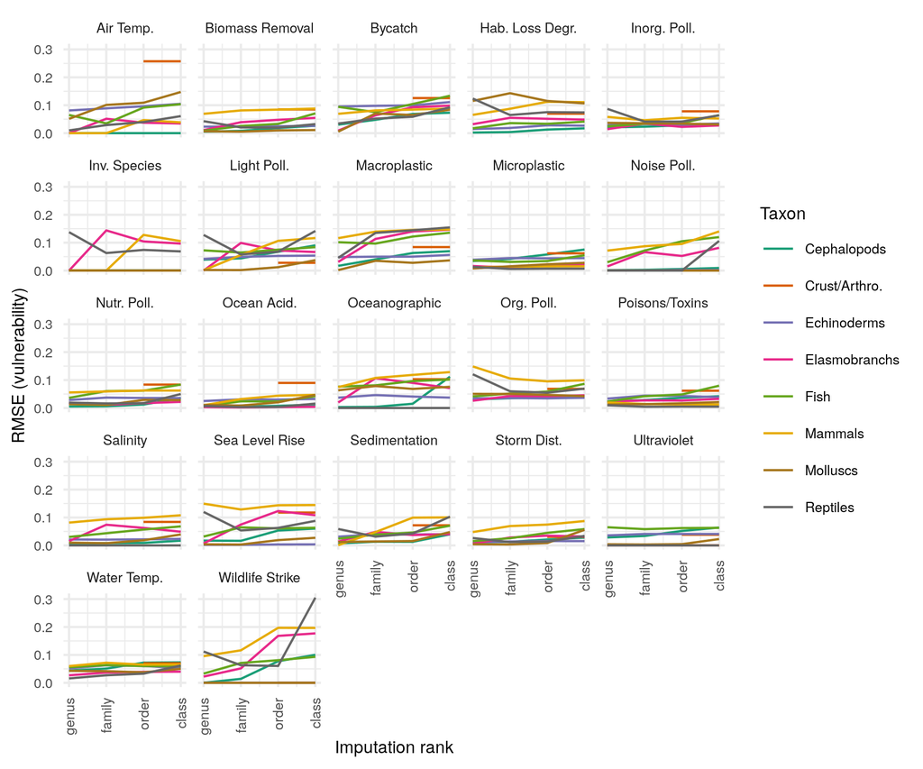

```r
str_fixes <- read_csv(here('_raw_data/clean_taxa_and_strs.csv')) %>%
  rename(stressor = raw, str_lbl = clean)
tx_fixes <- read_csv(here('_raw_data/clean_taxa_and_strs.csv')) %>%
  rename(taxon = raw, tx_lbl = clean)

plot_df <- compare_rmse_df %>%
  gather(gf_level, rmse, -taxon, -stressor, -starts_with('n_')) %>%
  mutate(gf_level = factor(gf_level, levels = c('genus', 'family', 'order', 'class'))) %>%
  left_join(str_fixes, by = 'stressor') %>%
  left_join(tx_fixes, by = 'taxon')


p <- ggplot(plot_df, aes(x = as.integer(gf_level), y = rmse, group = tx_lbl, color = tx_lbl)) +
  geom_line() +
  facet_wrap(~str_lbl) +
  scale_x_continuous(breaks = 1:4, labels = c('genus', 'family', 'order', 'class')) +
  scale_color_brewer(palette = 'Dark2') +
  theme_minimal() +
  theme(text = element_text(size = 8),
        axis.text.x = element_text(angle = 90, hjust = 1, vjust = .5)) +
  labs(y = 'RMSE (vulnerability)',
       x = 'Imputation rank',
       color = 'Taxon')

ggsave(here('figs/up_down_gapfill_crossval.png'), height = 5, width = 6, dpi = 300)

knitr::include_graphics(here('figs/up_down_gapfill_crossval.png'))
```